# Assignment 2

Chiebuka Onwuzurike

### RocketFuel

Read the Data:

## 2.1 Did the campaign cause more purchases?

### Is this difference statistically significant?

Yes, the campaign caused more purchases. There is a difference of 0.00769245 between the mean of those who saw the campaign and those who didn’t. With as CI of (0.005950817 - 0.009434089 and a p-value of 2.2e-16, we are 95% confident that there is an effect.

```r
ttest = t.test(ads_data[test == 1, converted], ads_data[test == 0, converted])
ttest
```

```
##
##  Welch Two Sample t-test
##
## data:  ads_data[test == 1, converted] and ads_data[test == 0, converted]
## t = 8.6572, df = 26384, p-value < 2.2e-16
## alternative hypothesis: true difference in means is not equal to 0
## 95 percent confidence interval:
##  0.005950817 0.009434089
## sample estimates:
##  mean of x  mean of y
## 0.02554656 0.01785411
```

## 2.2 Was the campaign profitable?

### 2.2.a How much more profit did TaskaBella make by running the campaign (excluding advertising costs) (8 points)

#### Hint: the profit per conversion is given on page 2 of the case.

Yes the campaign was profitable. With an average treatment effect (ATE) of 0.007692453 the profit if everyone was shown the add would be $180,957.6 dollars.

```r
profit_ad = ttest$estimate[1] * ads_data[,.N] * 40
profit_noad = ttest$estimate[2] * ads_data[,.N] * 40
# OR
ATE = ttest$estimate[1] - ttest$estimate[2]
profit_ate = ATE * ads_data[,.N] * 40

profit_per_person = profit_ate/ads_data[,.N]
profit_ate
```

```
## mean of x
##  180957.6
```

### 2.2.b What was the cost of the campaign? (7 points)

#### Hint: The cost per thousand impressions is $9

The cost of the campaign was $131,374.6.

```r
ad_spend_total = sum(ads_data$tot_impr)/1000*9
ad_spend_per_person = ad_spend_total/ads_data[,.N]
ad_spend_total
```

```
## [1] 131374.6
```

### 2.2.c Calculate the ROI of the campaign. Was the campaign profitable? (7 points)

The ROI is calculated by (Effect on Profits per Person - Cost of Ads per Person) / (Cost of Ads per Person)

With a profit per person of 0.3076981 and a cost per person of 0.2233879, the ROI is 0.3774164.

```r
ROI = (profit_per_person -ad_spend_per_person)/ad_spend_per_person
ROI
```

```
## mean of x
## 0.3774164
```

### 2.2.d What was the opportunity cost of including a control group — how much more could TaskaBella have made by not having a control group at all? (7 points)

If the 23,524 users were not test with the control advertisement they would have been more likely to convert. This 4% control group was an opportunity cost of 7,238.29 for TaskaBella.

```r
opp_cost = (ATE * ads_data[test == 0,.N] * 40)

opp_cost
```

```
## mean of x
##  7238.291
```

## 3 Did the number of impressions seen by each user influence the effectiveness of advertising?

### 3.a Create a chart of conversion rates as a function of the number of ads displayed to users. Plot conversion rates for those who were in the control group and for those who were exposed to the (7 points)

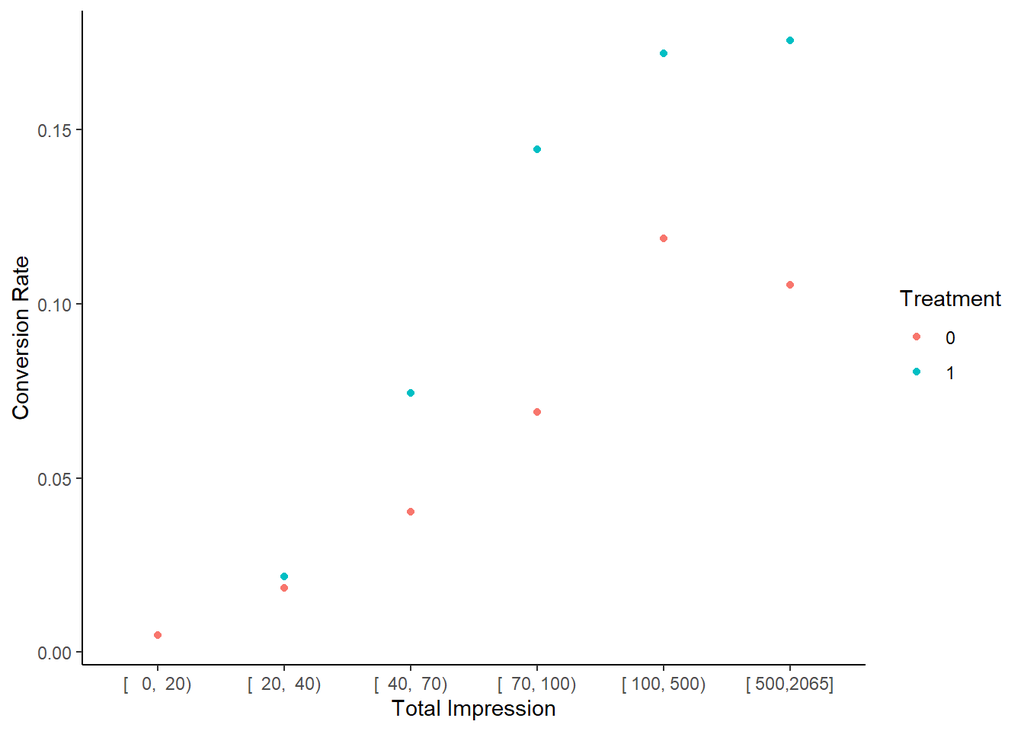

```r
### Create bins of the variable 'tot_impr'
ads_data[, group_tot_impr := cut2(tot_impr, c(0,20,40,70,100,500))]

aggregate_by_num <- ads_data[, list(conversion_rate = mean(converted), num_user = .N), by = list(group_tot_impr, test)]
this_plot <- ggplot(aggregate_by_num, aes(x = group_tot_impr, y = conversion_rate, color = factor(test))) + geom_point() + xlab("Total Impression") + ylab("Conversion Rate") + theme_classic() + labs(color="Treatment")
this_plot
```

```r
aggregate_by_num
```

```
##     group_tot_impr test conversion_rate num_user
##  1:    [ 100, 500)    1     0.171795693    21869
##  2:    [  70, 100)    1     0.144159334    18979
##  3:    [  20,  40)    1     0.021735350   109269
##  4:    [ 500,2065]    1     0.175438596      570
##  5:    [   0,  20)    1     0.004820131   364098
##  6:    [  40,  70)    1     0.074309126    49792
##  7:    [ 100, 500)    0     0.118694362     1011
##  8:    [  20,  40)    0     0.018547141     4529
##  9:    [   0,  20)    0     0.004965572    15104
## 10:    [  70, 100)    0     0.068840580      828
## 11:    [  40,  70)    0     0.040334481     2033
## 12:    [ 500,2065]    0     0.105263158       19
```

### 3.c Based on the above figure, suggest a follow-up experiment. What is the treatment and what is the control? Answer should be 1 paragraph. (8 points)

The first experiment concluded in that the campaign is in fact effective. Let’s say a large part of the CPM is the size of the add. A follow-up experiment would be to see what size of the ad is the optimal size given the increase/decrease in cost and effective. The control would be the add at the current size and the treatment would be a smaller ad.

## 4 Calculate the power of this experiment.

### 4.1 Calculate cohen’s D. This is the treatment effect on conversion divided by the standard deviation of conversion.

Hint, the standard deviation function is: sd With an standard deviation for conversion of 0.1568 and and ATE of 0.007692, Cohen’s D is 0.04904.

```r
sd_conversion = sd(ads_data$converted)
sd_conversion
```

```
## [1] 0.1568499
```

```r
cohensd = ATE/sd_conversion
cohensd
```

```
##  mean of x
## 0.04904339
```

### 4.2 Use the pwr.t2n.test function to calcualte the power of the experiment:

Hint, we can calculate the number of individuals in a subset of the data like this: ads_data[test == 1, .N]

The power is 1.

```r
pwr.t2n.test(n1 = ads_data[test == 1, .N], n2 = ads_data[test == 0, .N], d = cohensd, sig.level = .05, power = NULL)
```

```
##
##      t test power calculation
##
##              n1 = 564577
##              n2 = 23524
##               d = 0.04904339
##       sig.level = 0.05
##           power = 1
##     alternative = two.sided
```

### 4.3 What would the power be instead if the true effect had a cohen’s D of .01?

Hint: Copy the above function and modify accordingly.

The power would be 0.3240307.

```r
pwr.t2n.test(n1 = ads_data[test == 1, .N], n2 = ads_data[test == 0, .N], d = .01, sig.level = .05, power = NULL)
```

```
##
##      t test power calculation
##
##              n1 = 564577
##              n2 = 23524
##               d = 0.01
##       sig.level = 0.05
##           power = 0.3240307
##     alternative = two.sided
```

### 4.4 What would the power be instead if the true effect had a cohen’s of .01 and the sample was equally split between treatment and control?

Hint: Copy the above function and modify accordingly.

The power would be 0.9695635.

```r
pwr.t2n.test(n1 = ads_data[, .N]/2, n2 = ads_data[, .N]/2, d = .01, sig.level = .05, power = NULL)
```

```
##
##      t test power calculation
##
##              n1 = 294050.5
##              n2 = 294050.5
##               d = 0.01
##       sig.level = 0.05
##           power = 0.9695635
##     alternative = two.sided
```

### 5 Case writeup + Case Discussion in Class, be prepared to discuss!

I would first start off the meeting with TaskaBella and congratulate them on a profitable and successful product because it brough in 593,720 dollars worth of profit. Then I would have shifted the discussion to how much was due to the ads and how much was due to the great product and word of mouth. I would make a say that around 30% of the profit was due to our ads which equals 180,957.6 dollars. I would explain how the average conversion rate of the control group that without seeing our ads was about 1.78%. However the conversion rate for the treatment group that saw the ads was about 2.55%; a 43% increase. I would then drive home the point by talking about the 37.74% ROI given the fact the profit per person was 0.3076981 and a cost per person of 0.2233879. They would obviously be a little skeptical, and want us to back up our points as we promised. I would restate how we didn’t show the ads to 4% of our target group, which did have an opportunity cost 7,238.29 dollars of profit. However I would drive home the fact that this cost was necessary to be 95% confident that our ads did have effect we are claiming. For the engineers in the room I would highlight the p-value of 2.2e-16 and our statistical power of 1 given our Cohen’s D of 0.04904339. Being the good salesman I am, I would finally shift the conversation to follow up ads and experiments. I would talk about how we can do a follow experiment to see what size ad is most effective and efficeint.

# How long did this assignment take you to do (hours)? How hard was it (easy, reasonable, hard, too hard)?

On and off for a few days but I would say a total of 4-6 hours. For me it took a very long time wrapping my mind around what was being asked of me. I don’t know, it felt like the jump from our theoretical “conversations” about the topics during lectures, to actual applications of the material was quite large. Question 2 and slightly 3 took the bulk of the time.